# 11.17.26.md.linear.Model

Martin Djamongue

2026-11-17

#### Goal:

Developing working knowledge of linear models in R: fitting them, reading diagnostic plots, and judging when a model is (or is not) correctly specified.

#### sample Simulation foundations on a linear and quadratic terms.

general approach;

- Create the simulated dataset.
- Fit the three linear models described above.
- Use the predict() function to obtain observed and fitted values.
- Use the resid() function to obtain residual values.
- Plot the observed and fitted data points, as well as the residual values.

```r
# Starting with default variables to assess association between x and y
# General f(x) = 20 + 10*x + 5x^2 to test with models.
# + noise = rnorm(100, 0, 1.5)
x <- 1:20
y <- 20 + 10 * 1:20 + 5 * (1:20)^2 + rnorm(20, 0, 200)
dfr <- data.frame(x, y)

fx <- 20 + 10 * x + 5 * x^2 # function without noise
fxn <- 20 + 10 * 1:20 + 5 * (1:20)^2 + rnorm(20, 0, 200) # function + noise


# model 1; m1 :  intercept only (y~1) ;

m1 <- lm(y ~ 1, data = dfr)
summary(m1)
```

```
##
## Call:
## lm(formula = y ~ 1, data = dfr)
##
## Residuals:
##      Min       1Q   Median       3Q      Max
## -1049.14  -595.97   -96.74   577.54  1531.67
##
## Coefficients:
##             Estimate Std. Error t value Pr(>|t|)
## (Intercept)    905.4      157.6   5.744 1.55e-05 ***
## ---
## Signif. codes:  0 '***' 0.001 '**' 0.01 '*' 0.05 '.' 0.1 ' ' 1
##
## Residual standard error: 705 on 19 degrees of freedom
```

```r
# model 2; m2 : intercept and slope (y~x)

m2 <- lm(y ~ x, data = dfr)
summary(m2)
```

```
##
## Call:
## lm(formula = y ~ x, data = dfr)
##
## Residuals:
##    Min     1Q Median     3Q    Max
## -434.6 -160.0    8.3  110.9  585.9
##
## Coefficients:
##             Estimate Std. Error t value Pr(>|t|)
## (Intercept)  -262.92     120.43  -2.183   0.0425 *
## x             111.27      10.05  11.068 1.83e-09 ***
## ---
## Signif. codes:  0 '***' 0.001 '**' 0.01 '*' 0.05 '.' 0.1 ' ' 1
##
## Residual standard error: 259.2 on 18 degrees of freedom
## Multiple R-squared:  0.8719, Adjusted R-squared:  0.8648
## F-statistic: 122.5 on 1 and 18 DF,  p-value: 1.832e-09
```

```r
# model 3, m3 = intercept, slope, and curvature,quadratic term x^2 #(y~x+I(x^2)).

m3 <- lm(y ~ x + I(x^2), data = dfr)
summary(m3)
```

```
##
## Call:
## lm(formula = y ~ x + I(x^2), data = dfr)
##
## Residuals:
##    Min     1Q Median     3Q    Max
## -340.4 -210.0  -16.7  155.4  474.5
##
## Coefficients:
##             Estimate Std. Error t value Pr(>|t|)
## (Intercept)  -43.148    186.366  -0.232    0.820
## x             51.334     40.873   1.256    0.226
## I(x^2)         2.854      1.891   1.510    0.149
##
## Residual standard error: 250.5 on 17 degrees of freedom
## Multiple R-squared:  0.887,  Adjusted R-squared:  0.8738
## F-statistic: 66.75 on 2 and 17 DF,  p-value: 8.909e-09
```

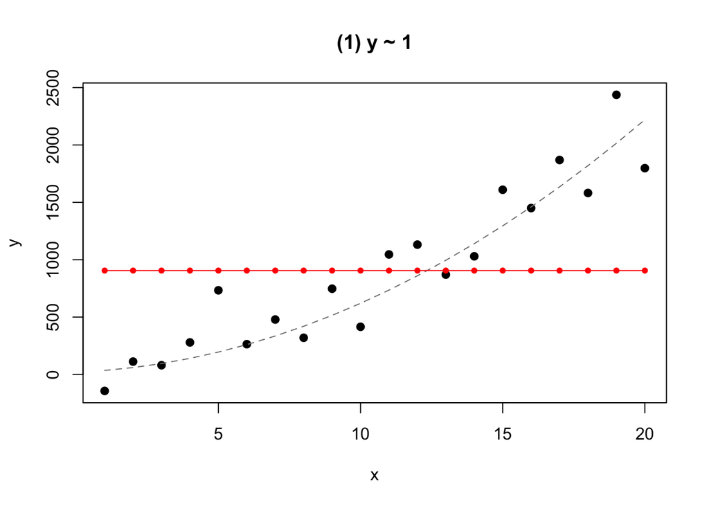

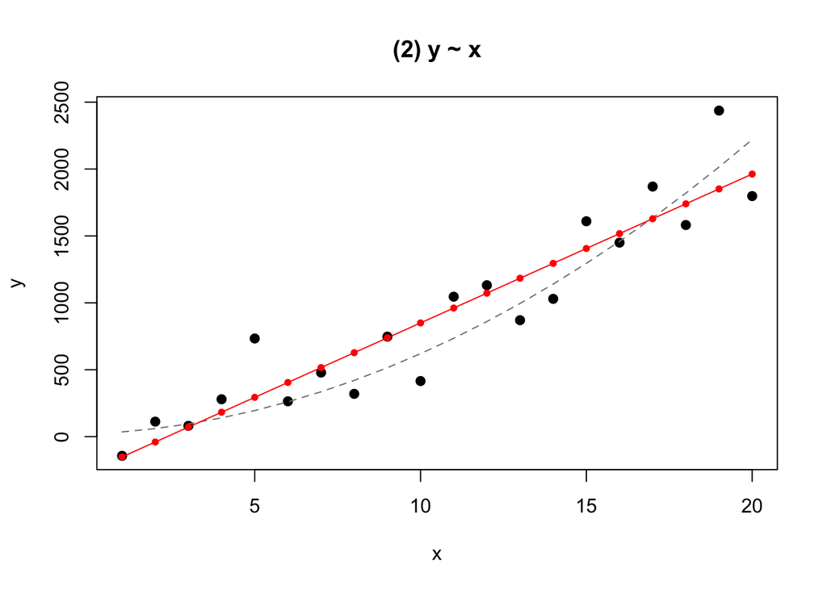

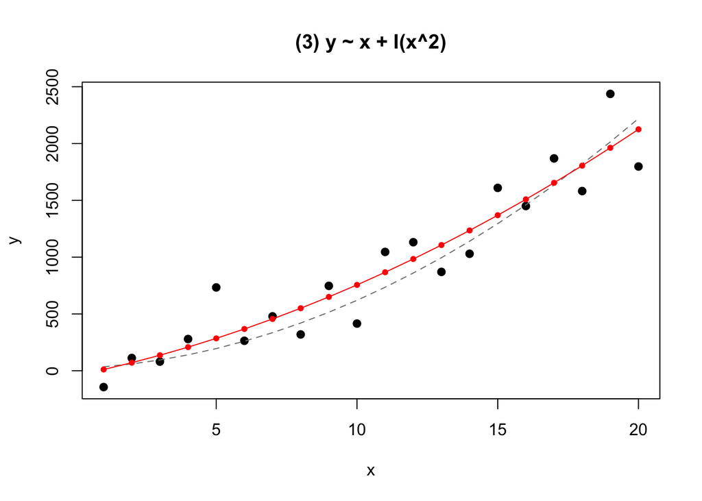

```r
#----predicting observed values
m1.obs <- predict(m1)
m2.obs <- predict(m1)
m3.obs <- predict(m1)

#---- obtaining residuals values

m1.resid <- resid(m1)
m2.resid <- resid(m2)
m3.resid <- resid(m3)

# plotting observed and fitted + residuals

for (i in 1:3) {
  lms <- list(m1, m2, m3)[[i]] # model i
  plot(dfr$x, dfr$y,
    pch = 19,
    xlab = "x", ylab = "y",
    main = c("(1) y ~ 1", "(2) y ~ x", "(3) y ~ x + I(x^2)")[i]
  )
  lines(dfr$x, fx, lty = 2, col = "grey50") # default
  points(dfr$x, predict(lms), col = "red", pch = 20) # fitted points
  lines(dfr$x, predict(lms), col = "red") # fitted shape
}
```

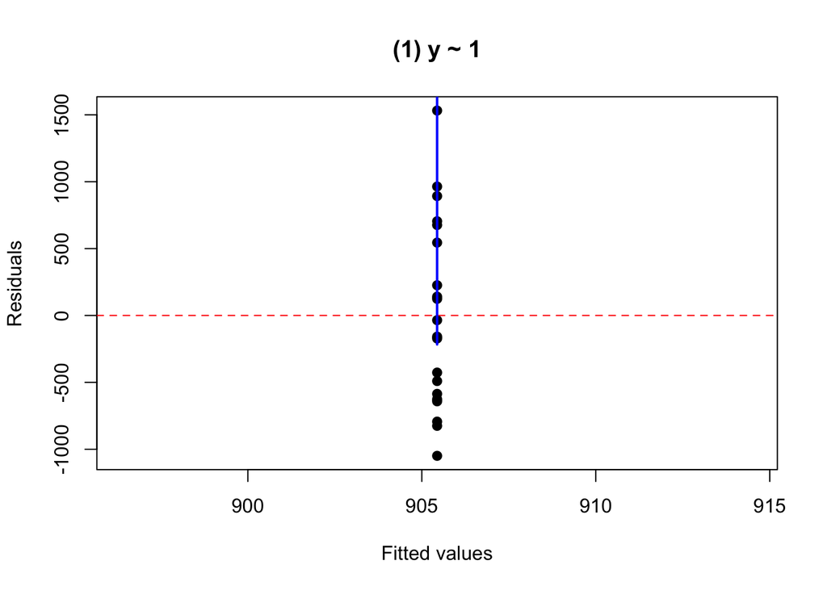

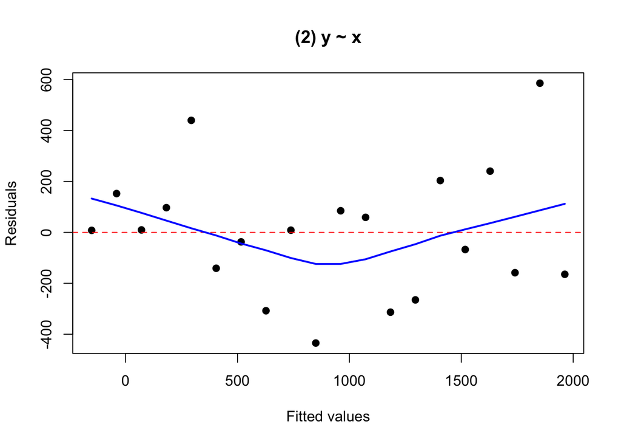

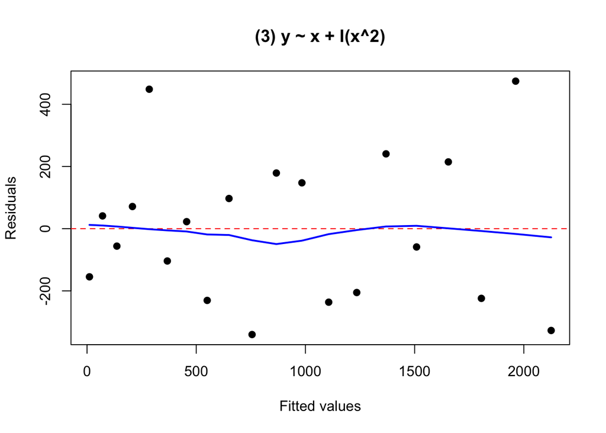

```r
for (i in 1:3) {
  lms <- list(m1, m2, m3)[[i]]
  plot(fitted(lms), resid(lms),
    pch = 19,
    xlab = "Fitted values", ylab = "Residuals",
    main = c("(1) y ~ 1", "(2) y ~ x", "(3) y ~ x + I(x^2)")[i]
  )
  abline(h = 0, lty = 2, col = "red")
  lines(lowess(fitted(lms), resid(lms)), col = "blue", lwd = 2)
}
```

```r
compare <- data.frame(
  model = c("(1) y ~ 1", "(2) y ~ x", "(3) y ~ x + I(x^2)"),
  intercept = c(coef(m1)[1], coef(m2)[1], coef(m3)[1]),
  slope.x = c(NA, coef(m2)[2], coef(m3)[2]),
  coef.x2 = c(NA, NA, coef(m3)[3]),
  sigma = c(
    summary(m1)$sigma, summary(m2)$sigma,
    summary(m3)$sigma
  ),
  R.squared = c(
    summary(m1)$r.squared, summary(m2)$r.squared,
    summary(m3)$r.squared
  ),
  adj.R.squared = c(
    summary(m1)$adj.r.squared,
    summary(m2)$adj.r.squared,
    summary(m3)$adj.r.squared
  ),
  RSS = c(sum(m1.resid^2), sum(m2.resid^2), sum(m3.resid^2))
)
```

#### Part B: Applying it to real data( GEO dataset )

```r
# functions

GEODataDownload <- function(DS, gpl, gsm, PlateAnnotInfo, GenerateMetaData, Technology) {
  library(DESeq2)
  library(limma)
  library(data.table)
  if (Technology == "Array") {
    gset <- getGEO(DS)
    if (length(gset) > 1) idx <- grep(gpl, attr(gset, "names")) else idx <- 1
    gset <- gset[[idx]]
    fvarLabels(gset) <- make.names(fvarLabels(gset))
    comp <- gsub(" ", "", gsm)
    comp <- gsub(",", "", comp)
    gsms <- paste0(comp)
    #### Set up raw names ####
    sml <- c()
    for (i in 1:nchar(gsms)) {
      sml[i] <- substr(gsms, i, i)
    }
    ex <- exprs(gset)
    qx <- as.numeric(quantile(ex, c(0., 0.25, 0.5, 0.75, 0.99, 1.0), na.rm = T))
    LogC <- (qx[5] > 100) ||
      (qx[6] - qx[1] > 50 && qx[2] > 0) ||
      (qx[2] > 0 && qx[2] < 1 && qx[4] < 2)
    if (LogC) {
      ex[which(ex <= 0)] <- NaN
      exprs(gset) <- log2(ex)
    }
    sml <- paste("G", sml, sep = "")
    f1 <- as.factor(sml)
    gset$description2 <- f1
    design <- model.matrix(~ description2 + 0, gset)
    colnames(design) <- levels(f1)
    fit <- lmFit(gset, design)
    cont.matrix <- makeContrasts(G1 - G0, levels = design)
    fit2 <- contrasts.fit(fit, cont.matrix)
    fit2 <- eBayes(fit2, 0.01)
    tT <- topTable(fit2, adjust = "fdr", sort.by = "B", number = 25000000000)
    #### subset ####
    ex2 <- data.table(subset(tT, select = c("ID", "logFC", "P.Value", "adj.P.Val")))
    ex2$ID <- as.character(ex2$ID)
    #### annotate with gene names ####
    plat <- PlateAnnotInfo[GPLID == gpl, ][, !"GPLID", with = FALSE]
    if (nrow(plat) == 0) {
      print(paste("There is no annotation information available for", gpl))
    }
    plat$ID <- as.character(plat$ID)
    plat <- plat[!duplicated(plat$ID), ]
    ex2 <- merge(plat, ex2, by = "ID")
    ex2$ID <- as.character(ex2$ID)
    exraw <- data.table(ex)
    exraw$ID <- as.character(rownames(ex))
    #### annotate raw data with gene names ####
    ex2 <- merge(ex2, exraw, by = "ID")
    #### Generate Meta Data ####
    Pdat <- pData(gset)
    #### Add Meta data ####
    Pdat <- as.data.table(Pdat)
    return(list(Data = ex2, MetaData = Pdat))
  }

  if (Technology == "RNAseq") {
    ACC <- paste("acc=", DS, sep = "")
    file <- paste("file=", DS, "_raw_exprs_GRCh38.p13_NCBI.tsv.gz", sep = "")
    comp <- gsub(" ", "", gsm)
    comp <- gsub(",", "", comp)
    gsms <- paste0(comp)
    #### Set up DEG names ####
    urld <- "https://www.ncbi.nlm.nih.gov/geo/download/?format=file&type=rnaseq_exprs"
    path <- paste(urld, ACC, file, sep = "&")
    tbl <- as.matrix(data.table::fread(path, header = T, colClasses = "integer"), rownames = "GeneID")
    exraw <- tbl
    apath <- paste(urld, "type=rnaseq_exprs", "file=Human.GRCh38.p13.annot.tsv.gz", sep = "&")
    annot <- tryCatch(data.table::fread(apath, header = T, quote = "", stringsAsFactors = F, data.table = F),
      error = function(e) NULL
    )
    ## FALLBACK (only change to the notes' function): if NCBI serves a captcha page instead of the
    ## annotation file, use NCBI's Homo_sapiens.gene_info (the same GeneID/Symbol/description source)
    if (is.null(annot) || !all(c("GeneID", "Symbol", "Description") %in% names(annot))) {
      annot <- data.table::fread("https://ftp.ncbi.nlm.nih.gov/gene/DATA/GENE_INFO/Mammalia/Homo_sapiens.gene_info.gz",
        header = T, quote = "", stringsAsFactors = F, data.table = F
      )
      names(annot)[names(annot) == "#tax_id"] <- "tax_id"
      annot <- annot[, c("GeneID", "Symbol", "description")]
      names(annot)[3] <- "Description"
    }
    rownames(annot) <- annot$GeneID
    sml <- strsplit(gsms, split = "")[[1]]
    sel <- which(sml != "X")
    sml <- sml[sel]
    tbl <- tbl[, sel]
    gs <- factor(sml)
    groups <- make.names(c("Ctrl", "Tx"))
    levels(gs) <- groups
    sample_info <- data.frame(Group = gs, row.names = colnames(tbl))
    keep <- rowSums(tbl >= 10) >= min(table(gs))
    tbl <- tbl[keep, ]
    ds <- DESeqDataSetFromMatrix(countData = tbl, colData = sample_info, design = ~Group)
    ds <- DESeq(ds, test = "Wald", sfType = "poscount")
    r <- results(ds, contrast = c("Group", groups[2], groups[1]), alpha = 0.05, pAdjustMethod = "fdr")
    tT <- r[order(r$padj)[1:length(r$padj)], ]
    tT <- merge(as.data.frame(tT), annot, by = 0, sort = F)
    tT <- subset(tT, select = c("GeneID", "padj", "pvalue", "lfcSE", "stat", "log2FoldChange", "baseMean", "Symbol", "Description"))
    #### subset ####
    ex2 <- data.table(subset(tT, select = c("GeneID", "Symbol", "Description", "log2FoldChange", "pvalue", "padj")))
    #### Adjust column names ####
    setnames(ex2, c("GeneID", "Symbol", "Description"), c("ENTREZID", "SYMBOL", "GENENAME"))
    #### Get Raw data ####
    GeneID <- as.integer(rownames(exraw))
    exraw <- as.data.table(exraw)
    #### Update column names ####
    exraw$ENTREZID <- GeneID
    #### merge FC and raw data together ####
    mer <- merge(ex2, exraw, by = "ENTREZID")
    return(mer)
  }
}
```

#### 2: loading data

```r
library(GEOquery)
library(data.table)


##
gse <- getGEO("GSE19420")[[1]]
metadata <- pData(gse)
expr <- exprs(gse)

identical(colnames(expr), metadata$geo_accession) # checking if both matches
```

```
## [1] TRUE
```

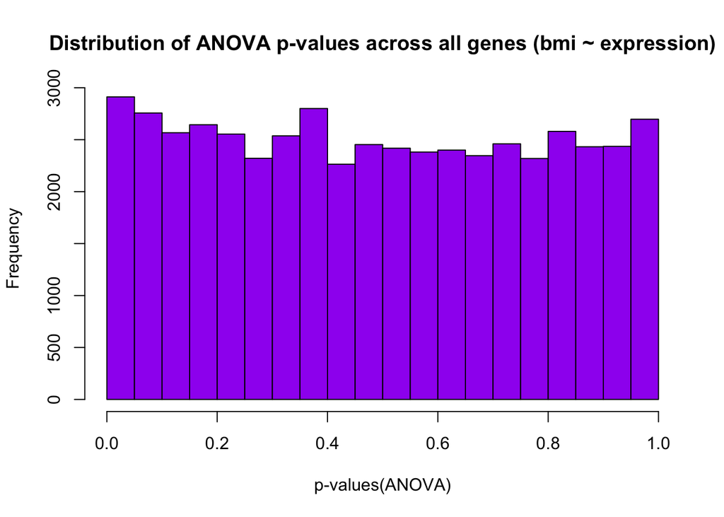

```r
## -Clean metadata ----
metadata$group <- sub("group: ", "", metadata$characteristics_ch1)
metadata$age <- as.numeric(sub("age: ", "", metadata$characteristics_ch1.1))
metadata$bmi <- as.numeric(sub("bmi: ", "", metadata$characteristics_ch1.2))

## ---- 3. Loop: one linear model per gene ---------------------------
cont_var <- metadata$bmi # the continuous dependent variable

results <- data.frame(
  probe = rownames(expr),
  slope = NA,
  pvalue = NA
)

for (i in 1:nrow(expr)) {
  fit <- lm(cont_var ~ expr[i, ])
  results$slope[i] <- coef(fit)[2]
  results$pvalue[i] <- anova(fit)[["Pr(>F)"]][1]
}

hist(results$pvalue,
  col = "purple",
  main = "Distribution of ANOVA p-values across all genes (bmi ~ expression)",
  xlab = "p-values(ANOVA)"
)
```

```r
# assessing e most extreme genes

# summary(results$pvalue)


#      Min.   1st Qu.    Median      Mean   3rd Qu.      Max.       NAs
# 0.0000492 0.2337905 0.4840769 0.4914808 0.7475298 0.9999971      4397

smallest_p_loc <- which.min(results$pvalue) # location of smallest pvalue
biggest_p_loc <- which.max(results$pvalue) # location of largest pvalue

results[smallest_p_loc, ]
```

```
##             probe     slope       pvalue
## 18124 208708_x_at -8.991045 4.920106e-05
```

```r
results[biggest_p_loc, ]
```

```
##           probe        slope    pvalue
## 48487 239237_at 4.135956e-06 0.9999971
```

```r
# Most significant: model summary, ANOVA, diagnostics

fit_most <- lm(cont_var ~ expr[smallest_p_loc, ])
summary(fit_most)
```

```
##
## Call:
## lm(formula = cont_var ~ expr[smallest_p_loc, ])
##
## Residuals:
##     Min      1Q  Median      3Q     Max
## -4.6917 -2.1742 -0.4935  1.9274  6.6197
##
## Coefficients:
##                        Estimate Std. Error t value Pr(>|t|)
## (Intercept)             119.866     19.181   6.249 2.11e-07 ***
## expr[smallest_p_loc, ]   -8.991      1.976  -4.549 4.92e-05 ***
## ---
## Signif. codes:  0 '***' 0.001 '**' 0.01 '*' 0.05 '.' 0.1 ' ' 1
##
## Residual standard error: 3.208 on 40 degrees of freedom
## Multiple R-squared:  0.341,  Adjusted R-squared:  0.3245
## F-statistic: 20.69 on 1 and 40 DF,  p-value: 4.92e-05
```

```r
anova(fit_most)
```

```
## Analysis of Variance Table
##
## Response: cont_var
##                        Df Sum Sq Mean Sq F value   Pr(>F)
## expr[smallest_p_loc, ]  1 212.97 212.967  20.694 4.92e-05 ***
## Residuals              40 411.65  10.291
## ---
## Signif. codes:  0 '***' 0.001 '**' 0.01 '*' 0.05 '.' 0.1 ' ' 1
```

```r
# plot of extreme with the smallest pvalue
genes_table <- Table(getGEO("GPL570"))

most_sig_gene <- genes_table[smallest_p_loc, "Gene Symbol"]
most_sig_gene
```

```
## [1] "EIF5"
```

```r
least_sig_gene <- genes_table[biggest_p_loc, "Gene Symbol"]
least_sig_gene
```

```
## [1] "TRG-AS1"
```

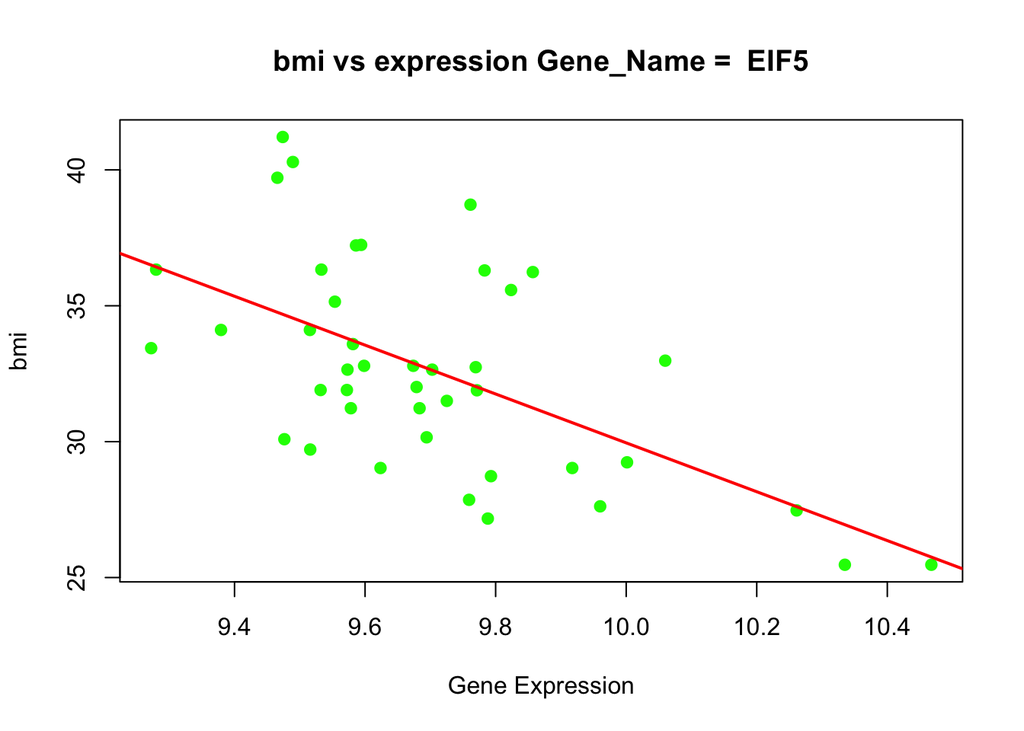

```r
plot(expr[smallest_p_loc, ], cont_var,
  pch = 19, col = "green",
  main = paste("bmi vs expression Gene_Name = ", most_sig_gene),
  xlab = "Gene Expression", ylab = "bmi"
)
abline(fit_most, col = "red", lwd = 2)
```

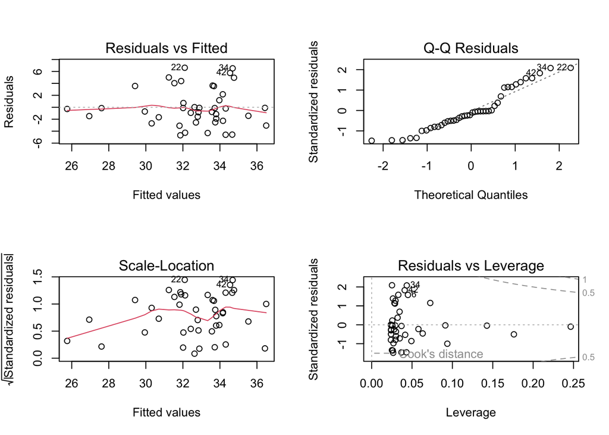

```r
par(mfrow = c(2, 2))
plot(fit_most)
```

```r
#-#Least significant: model summary, ANOVA, diagnostics
fit_least <- lm(cont_var ~ expr[biggest_p_loc, ])
summary(fit_least)
```

```
##
## Call:
## lm(formula = cont_var ~ expr[biggest_p_loc, ])
##
## Residuals:
##    Min     1Q Median     3Q    Max
## -7.170 -2.835  0.010  2.833  8.570
##
## Coefficients:
##                        Estimate Std. Error t value Pr(>|t|)
## (Intercept)           3.264e+01  4.304e+00   7.584 2.92e-09 ***
## expr[biggest_p_loc, ] 4.136e-06  1.113e+00   0.000        1
## ---
## Signif. codes:  0 '***' 0.001 '**' 0.01 '*' 0.05 '.' 0.1 ' ' 1
##
## Residual standard error: 3.952 on 40 degrees of freedom
## Multiple R-squared:  3.453e-13,  Adjusted R-squared:  -0.025
## F-statistic: 1.381e-11 on 1 and 40 DF,  p-value: 1
```

```r
anova(fit_least)
```

```
## Analysis of Variance Table
##
## Response: cont_var
##                       Df Sum Sq Mean Sq F value Pr(>F)
## expr[biggest_p_loc, ]  1   0.00   0.000       0      1
## Residuals             40 624.62  15.616
```

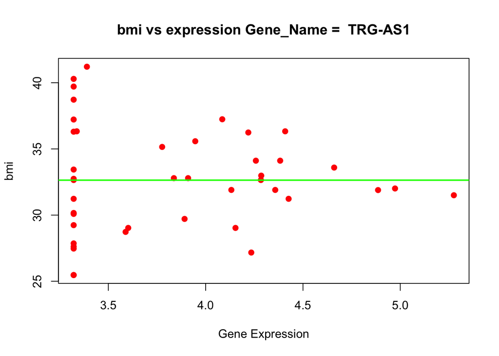

```r
# plot
par(mfrow = c(1, 1))

plot(expr[biggest_p_loc, ], cont_var,
  pch = 19, col = "red",
  main = paste("bmi vs expression Gene_Name = ", least_sig_gene),
  xlab = "Gene Expression", ylab = "bmi"
)
abline(fit_least, col = "green", lwd = 2)
```

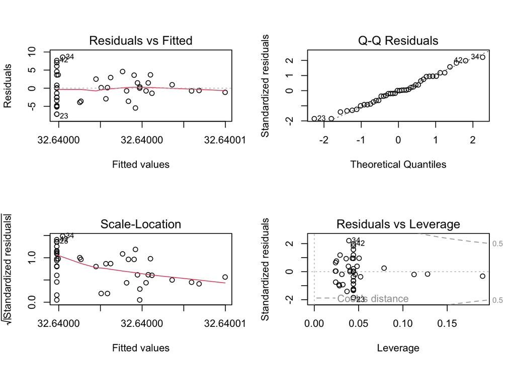

```r
# diagnostic plots

par(mfrow = c(2, 2))
plot(fit_least)
```

**Discussion and conclusion** Based on the problem, the Null and Alternative hypothesis are set as; - H0: genes expression level and BMI are independent - HA: genes expression level and BMI are not independent

Based on the on the linear model fit across genes, the most extreme genes considered to have some effect on the association between Gene expression and BMI were “EIF5” and “TRG-AS1”. EIF5 based on linear model fit and anova shows a negative ( slope = -8.991 ) and and adjusted effect size of about 32%. ANOVA should a significant association between the 2 variables ( p-value = 4.92e-05), suggesting evidence for the alternative hypothesis. In “TRG-AS1” , the model find barely to no relationship between bmi and TRG-AS1, returning a slope = 4.136e-06 and an effect size (R-squared: -0.025 ). ANOVA returns a p-value = 1, suggesting evidence for the null hypothesis. Hence we conclude that this particular gene (TRG-AS1) has the least effect on the relationship between bmi and gene expression. Diagnostic plots in EIF5 follows the. normal distribution, better variance compared to TRG-AS1.

#### 3 LOESS and GAM for the top gene, compared with the linear fit

```r
library(mgcv)


bmi <- cont_var # y-var
most_sig_gene_exp <- as.numeric(expr[smallest_p_loc, ]) # x_var

fit_most <- lm(cont_var ~ most_sig_gene_exp) # gene = EIF5
fit_loess <- loess(cont_var ~ most_sig_gene_exp, span = 0.5)
fit_gam <- gam(bmi ~ s(most_sig_gene_exp), method = "REML")
summary(fit_gam)
```

```
##
## Family: gaussian
## Link function: identity
##
## Formula:
## bmi ~ s(most_sig_gene_exp)
##
## Parametric coefficients:
##             Estimate Std. Error t value Pr(>|t|)
## (Intercept)   32.640      0.495   65.94   <2e-16 ***
## ---
## Signif. codes:  0 '***' 0.001 '**' 0.01 '*' 0.05 '.' 0.1 ' ' 1
##
## Approximate significance of smooth terms:
##                      edf Ref.df     F  p-value
## s(most_sig_gene_exp)   1      1 20.69 4.95e-05 ***
## ---
## Signif. codes:  0 '***' 0.001 '**' 0.01 '*' 0.05 '.' 0.1 ' ' 1
##
## R-sq.(adj) =  0.324   Deviance explained = 34.1%
## -REML = 107.12  Scale est. = 10.291    n = 42
```

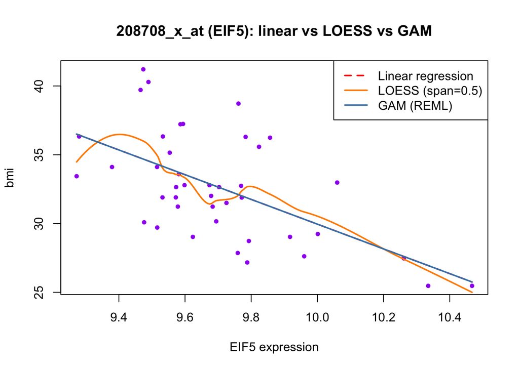

```r
g.seq <- seq(min(most_sig_gene_exp), max(most_sig_gene_exp), length.out = 200)
pred.lm <- predict(fit_most, newdata = data.frame(most_sig_gene_exp = g.seq))
pred.loess <- predict(fit_loess, newdata = data.frame(most_sig_gene_exp = g.seq))
pred.gam <- predict(fit_gam, newdata = data.frame(most_sig_gene_exp = g.seq))

plot(most_sig_gene_exp, bmi,
  pch = 16, col = "purple", cex = 0.8,
  xlab = "EIF5 expression", ylab = "bmi",
  main = "208708_x_at (EIF5): linear vs LOESS vs GAM"
)
lines(g.seq, pred.lm, col = "red", lwd = 2, lty = 2)
lines(g.seq, pred.loess, col = "darkorange", lwd = 2)
lines(g.seq, pred.gam, col = "steelblue", lwd = 2)
legend("topright", c("Linear regression", "LOESS (span=0.5)", "GAM (REML)"),
  col = c("red", "darkorange", "steelblue"), lwd = 2, lty = c(2, 1, 1)
)
```

```r
# Model comparison: linear vs. GAM using AIC:

lm.aic <- AIC(fit_most)
lm.aic
```

```
## [1] 221.0561
```

```r
gam.aic <- AIC(fit_gam)
gam.aic
```

```
## [1] 221.0565
```

```r
rss_loess <- sum(resid(fit_loess)^2)
n <- length(most_sig_gene_exp)

loess.aic <- n * log(rss_loess / n) + n * (log(2 * pi) + 1) +
  2 * (fit_loess$trace.hat + 1)
loess.aic
```

```
## [1] 229.7526
```

```r
diffs <- lm.aic - c(loess.aic, gam.aic)
diffs
```

```
## [1] -8.6964319712 -0.0003342663
```

**AIC conclusion:** Based on the AIC values, the GAM does not reveal any significant improvement compared to the linear model as they both return similar AIC values. GAM only confirms what the linear model already suggests. The loess model, however shows some deviation from the linear model, but this may be due to noise, rather than a signal.

#### 4. gene-by-gene analysis after normalization

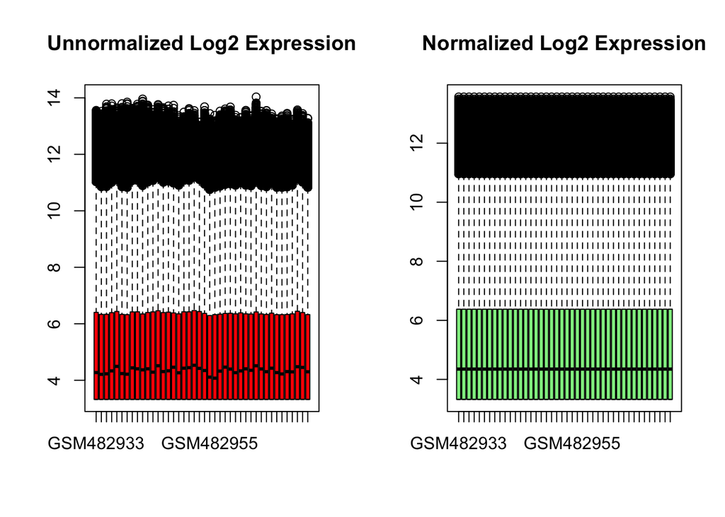

```r
library(limma)
expr_norm <- normalizeBetweenArrays(expr, method = "quantile")

# normalized vs unnormalized  boxplot
par(mfrow = c(1, 2))
boxplot(expr, col = "red", main = "Unnormalized Log2 Expression")
boxplot(expr_norm, col = "lightgreen", main = "Normalized Log2 Expression")
```

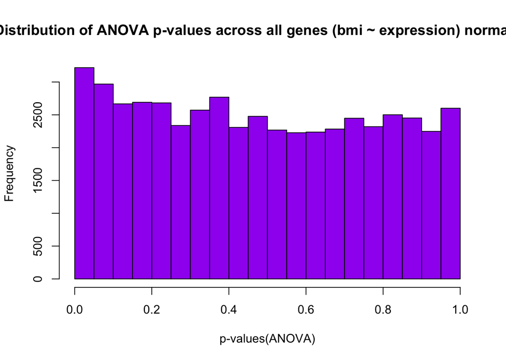

```r
# Linear model on normalized expression values

norm_pvalues <- data.frame(
  probe = rownames(expr_norm),
  slope = NA,
  pvalue = NA
)

for (i in 1:nrow(expr_norm)) {
  fit <- lm(cont_var ~ expr_norm[i, ])
  norm_pvalues$slope[i] <- coef(fit)[2]
  norm_pvalues$pvalue[i] <- anova(fit)[["Pr(>F)"]][1]
}

hist(norm_pvalues$pvalue,
  col = "purple",
  main = "Distribution of ANOVA p-values across all genes (bmi ~ expression) normalized",
  xlab = "p-values(ANOVA)"
)
```

```r
smallest_p_loc_norm <- which.min(norm_pvalues$pvalue) # location of smallest pvalue
biggest_p_loc_norm <- which.max(norm_pvalues$pvalue) # location of largest pvalue

norm_pvalues[smallest_p_loc_norm, ]
```

```
##             probe     slope       pvalue
## 18124 208708_x_at -9.366383 2.496738e-05
```

```r
norm_pvalues[biggest_p_loc_norm, ]
```

```
##             probe        slope    pvalue
## 32207 222927_s_at 0.0001276518 0.9999377
```

```r
# most significant p-value after normalization and it's gene name
fit_norm_most <- lm(cont_var ~ expr_norm[smallest_p_loc_norm, ])
summary(fit_norm_most)
```

```
##
## Call:
## lm(formula = cont_var ~ expr_norm[smallest_p_loc_norm, ])
##
## Residuals:
##     Min      1Q  Median      3Q     Max
## -4.9823 -2.0803 -0.4498  2.1629  6.4842
##
## Coefficients:
##                                  Estimate Std. Error t value Pr(>|t|)
## (Intercept)                       123.536     19.082   6.474 1.02e-07 ***
## expr_norm[smallest_p_loc_norm, ]   -9.366      1.966  -4.765 2.50e-05 ***
## ---
## Signif. codes:  0 '***' 0.001 '**' 0.01 '*' 0.05 '.' 0.1 ' ' 1
##
## Residual standard error: 3.156 on 40 degrees of freedom
## Multiple R-squared:  0.3621, Adjusted R-squared:  0.3461
## F-statistic:  22.7 on 1 and 40 DF,  p-value: 2.497e-05
```

```r
anova(fit_norm_most)
```

```
## Analysis of Variance Table
##
## Response: cont_var
##                                  Df Sum Sq Mean Sq F value    Pr(>F)
## expr_norm[smallest_p_loc_norm, ]  1 226.16 226.165  22.704 2.497e-05 ***
## Residuals                        40 398.45   9.961
## ---
## Signif. codes:  0 '***' 0.001 '**' 0.01 '*' 0.05 '.' 0.1 ' ' 1
```

```r
# least significant p-value after normalization and it's gene name
fit_norm_least <- lm(cont_var ~ expr_norm[biggest_p_loc_norm, ])
summary(fit_norm_least)
```

```
##
## Call:
## lm(formula = cont_var ~ expr_norm[biggest_p_loc_norm, ])
##
## Residuals:
##    Min     1Q Median     3Q    Max
## -7.170 -2.835  0.010  2.833  8.570
##
## Coefficients:
##                                  Estimate Std. Error t value Pr(>|t|)
## (Intercept)                     3.264e+01  5.735e+00   5.691 1.28e-06 ***
## expr_norm[biggest_p_loc_norm, ] 1.277e-04  1.624e+00   0.000        1
## ---
## Signif. codes:  0 '***' 0.001 '**' 0.01 '*' 0.05 '.' 0.1 ' ' 1
##
## Residual standard error: 3.952 on 40 degrees of freedom
## Multiple R-squared:  1.545e-10,  Adjusted R-squared:  -0.025
## F-statistic: 6.18e-09 on 1 and 40 DF,  p-value: 0.9999
```

```r
anova(fit_norm_least) #
```

```
## Analysis of Variance Table
##
## Response: cont_var
##                                 Df Sum Sq Mean Sq F value Pr(>F)
## expr_norm[biggest_p_loc_norm, ]  1   0.00   0.000       0 0.9999
## Residuals                       40 624.62  15.616
```

```r
# gene names for the top and bottom genes
gene_names_norm <- Table(getGEO("GPL570"))

top_gene_norm <- gene_names_norm[smallest_p_loc_norm, "Gene Symbol"]
top_gene_norm
```

```
## [1] "EIF5"
```

```r
bottom_gene_norm <- gene_names_norm[biggest_p_loc_norm, "Gene Symbol"]
bottom_gene_norm
```

```
## [1] "CPLX3"
```